# LAB 10: Named Entity Recognition

```python
!pip install -q -U spacy[cuda11x] spacy-transformers
!pip install -q -U git+https://github.com/MantisAI/nervaluate
```

```python
!pip install -q https://github.com/explosion/spacy-models/releases/download/en_core_web_sm-3.7.1/en_core_web_sm-3.7.1-py3-none-any.whl
!pip install -q https://github.com/explosion/spacy-models/releases/download/en_core_web_lg-3.7.1/en_core_web_lg-3.7.1-py3-none-any.whl
```

```python
from collections import Counter

import pandas as pd
import spacy
from IPython.display import display
from nervaluate import Evaluator
from sklearn.metrics import ConfusionMatrixDisplay
from spacy import displacy
from spacy.tokens import Doc, DocBin
from tqdm.auto import tqdm

pd.set_option("display.precision", 3)
spacy.require_gpu()
```

```
True
```

## Train model

The official way of training spaCy model is to use their command-line tools. The steps are:

1. Create DocBin files with training data (we already did this!)
2. Write a config file specifying the pipeline components you want to train. The easiest way to do this is using their automatic configuration tool: https://spacy.io/usage/training. For the model below, I selected: - Language = English - Components = ner - Hardware = CPU - Optimize for = efficiency
3. To create the config file, choose File > New > Text file in jupyter and create a blank file called `base_config.cfg`. Copy and paste the file contents from the configuration tool into the file and save it.
4. The configuration you just created only specifies a few of the options that are available. To create a complete config specification, run the command

```
python -m spacy init fill-config base_config.cfg config.cfg
```

5. Now you're ready to train. The training program will run until it decides that further improvement is unlikely or you interrupt it.

```
!python -m spacy train config.cfg \
    --output ner \
    --paths.train ./train.spacy \
    --paths.dev ./valid.spacy \
    --gpu-id 0
```

Some things you might want to try:

- Optimize = accuracy
- Hardware = GPU
- Try different GPU base models, e.g., change

```
   [components.transformer.model]
   @architectures = "spacy-transformers.TransformerModel.v3"
   name = "roberta-base"
   tokenizer_config = {"use_fast": true}
```

to

```
   [components.transformer.model]
   @architectures = "spacy-transformers.TransformerModel.v3"
   name = "distilbert-base-cased"
   tokenizer_config = {"use_fast": true}
```

- Bias model towards higher precision or recall (see https://spacy.io/usage/training#metrics)

```python
!python -m spacy init fill-config base_config.cfg config.cfg
```

```
✔ Auto-filled config with all values
✔ Saved config
config.cfg
You can now add your data and train your pipeline:
python -m spacy train config.cfg --paths.train ./train.spacy --paths.dev ./dev.spacy
```

```python
!python -m spacy train config.cfg \
    --output ner \
    --paths.train ./train.spacy \
    --paths.dev ./valid.spacy \
    --gpu-id 0
```

```
ℹ Saving to output directory: ner
ℹ Using GPU: 0

=========================== Initializing pipeline ===========================
✔ Initialized pipeline

============================= Training pipeline =============================
ℹ Pipeline: ['tok2vec', 'ner']
ℹ Initial learn rate: 0.001
E    #       LOSS TOK2VEC  LOSS NER  ENTS_F  ENTS_P  ENTS_R  SCORE
---  ------  ------------  --------  ------  ------  ------  ------
  0       0          0.00     45.39    0.00    0.00    0.00    0.00
  0     200       1455.43   2148.10    5.74    7.99    4.48    0.06
  0     400       1188.10   1220.90   28.86   45.13   21.22    0.29
  0     600        321.04    938.06   44.10   47.79   40.94    0.44
  0     800        349.24   1064.52   50.27   62.08   42.23    0.50
  0    1000        323.06    915.42   62.44   69.83   56.47    0.62
  0    1200        395.75   1009.78   68.93   73.56   64.84    0.69
  0    1400        614.22   1109.71   74.48   80.46   69.32    0.74
  1    1600        613.16   1189.14   76.12   78.03   74.30    0.76
  1    1800        585.53    995.43   78.45   81.30   75.80    0.78
  1    2000        872.14   1352.73   80.28   80.68   79.88    0.80
  2    2200        743.85   1196.92   82.98   85.20   80.88    0.83
  2    2400        934.13   1330.02   83.05   85.46   80.78    0.83
  3    2600        953.11   1219.61   84.82   85.90   83.76    0.85
  4    2800       1177.10   1103.84   84.81   86.85   82.87    0.85
  4    3000        991.84    975.71   85.31   86.49   84.16    0.85
  5    3200        760.08    854.68   85.35   86.27   84.46    0.85
  5    3400       5327.50    812.36   85.67   86.50   84.86    0.86
  6    3600       1081.09    694.38   85.28   86.02   84.56    0.85
  7    3800        669.23    753.00   86.38   87.85   84.96    0.86
  7    4000       1018.89    628.96   85.58   87.92   83.37    0.86
  8    4200        583.54    570.82   85.26   87.03   83.57    0.85
  8    4400       1082.99    571.30   85.86   88.06   83.76    0.86
  9    4600        777.12    575.83   86.03   88.10   84.06    0.86
  9    4800       2426.97    613.00   84.71   87.65   81.97    0.85
 10    5000       1125.27    574.67   85.28   86.96   83.67    0.85
 11    5200        818.21    455.77   86.37   87.93   84.86    0.86
 11    5400       1088.95    453.91   86.01   88.26   83.86    0.86
✔ Saved pipeline to output directory
ner/model-last
```

## Explore best model

The training program saves two models: `model-last` is the model produced in the final training step and `model-best` is the one that had the highest score. By default the score=f1, but you can change that using config options.

```python
ner = spacy.load("ner/model-best")
ner.pipeline
```

```
[('tok2vec', <spacy.pipeline.tok2vec.Tok2Vec at 0x7fb5d0940f50>),
 ('ner', <spacy.pipeline.ner.EntityRecognizer at 0x7fb5c1898270>)]
```

Load previously saved validation and test docs

```python
nlp = spacy.load("en_core_web_sm")

valid_docs = list(DocBin().from_disk("./valid.spacy").get_docs(nlp.vocab))
test_docs = list(DocBin().from_disk("./test.spacy").get_docs(nlp.vocab))
```

Define some helpful functions:

- `get_tokens(doc)` returns a `Doc`'s tokens as a list of strings
- `get_iob_tags(doc)` returns a `Doc`'s entity tags as a list of strings

```python
def get_tokens(doc):
    return [tok.orth_ for tok in doc]


def get_iob_tags(doc):
    return [
        "O" if tok.ent_iob_ == "O" else f"{tok.ent_iob_}-{tok.ent_type_}" for tok in doc
    ]
```

Now apply our best model to the test data:

```python
pred_docs = list(ner.pipe(Doc(ner.vocab, get_tokens(doc)) for doc in tqdm(test_docs)))
```

```python
displacy.render(pred_docs[10], style="ent")
```

On March 31 , 2010 , the members of our principal shareholder , FormCap Advisory , LLC ORG , James Altucher PER and Dan Kelly PER , filed forms 3 and 4 regarding their respective initial appointments as our Chairman and Director and reflecting the acquisition by FormCap Advisors , LLC ORG of the majority of our issued and outstanding common stock in November 2008 .

Measure performance on test data

```python
E = Evaluator(
    [get_iob_tags(doc) for doc in test_docs],
    [get_iob_tags(doc) for doc in pred_docs],
    tags=["LOC", "PER", "ORG", "MISC"],
    loader="list",
)
scores = E.evaluate()
```

These are overall scores across all four entity types:

```python
pd.DataFrame.from_dict(scores[0], orient="index")
```

|  | correct | incorrect | partial | missed | spurious | possible | actual | precision | recall | f1 |
| --- | --- | --- | --- | --- | --- | --- | --- | --- | --- | --- |
| ent_type | 779 | 43 | 0 | 82 | 64 | 904 | 886 | 0.879 | 0.862 | 0.870 |
| partial | 744 | 0 | 78 | 82 | 64 | 904 | 886 | 0.884 | 0.866 | 0.875 |
| strict | 727 | 95 | 0 | 82 | 64 | 904 | 886 | 0.821 | 0.804 | 0.812 |
| exact | 744 | 78 | 0 | 82 | 64 | 904 | 886 | 0.840 | 0.823 | 0.831 |

And broken down by entity type:

```python
for label in scores[1]:
    print(f"LABEL = {label}")
    display(pd.DataFrame.from_dict(scores[1][label], orient="index"))
    print()
```

```
LABEL = LOC
```

|  | correct | incorrect | partial | missed | spurious | possible | actual | precision | recall | f1 |
| --- | --- | --- | --- | --- | --- | --- | --- | --- | --- | --- |
| ent_type | 74 | 16 | 0 | 14 | 12 | 104 | 102 | 0.725 | 0.712 | 0.718 |
| partial | 71 | 0 | 19 | 14 | 12 | 104 | 102 | 0.789 | 0.774 | 0.782 |
| strict | 67 | 23 | 0 | 14 | 12 | 104 | 102 | 0.657 | 0.644 | 0.650 |
| exact | 71 | 19 | 0 | 14 | 12 | 104 | 102 | 0.696 | 0.683 | 0.689 |

```
LABEL = PER
```

|  | correct | incorrect | partial | missed | spurious | possible | actual | precision | recall | f1 |
| --- | --- | --- | --- | --- | --- | --- | --- | --- | --- | --- |
| ent_type | 61 | 4 | 0 | 5 | 0 | 70 | 65 | 0.938 | 0.871 | 0.904 |
| partial | 56 | 0 | 9 | 5 | 0 | 70 | 65 | 0.931 | 0.864 | 0.896 |
| strict | 55 | 10 | 0 | 5 | 0 | 70 | 65 | 0.846 | 0.786 | 0.815 |
| exact | 56 | 9 | 0 | 5 | 0 | 70 | 65 | 0.862 | 0.800 | 0.830 |

```
LABEL = ORG
```

|  | correct | incorrect | partial | missed | spurious | possible | actual | precision | recall | f1 |
| --- | --- | --- | --- | --- | --- | --- | --- | --- | --- | --- |
| ent_type | 399 | 14 | 0 | 39 | 21 | 452 | 434 | 0.919 | 0.883 | 0.901 |
| partial | 380 | 0 | 33 | 39 | 21 | 452 | 434 | 0.914 | 0.877 | 0.895 |
| strict | 372 | 41 | 0 | 39 | 21 | 452 | 434 | 0.857 | 0.823 | 0.840 |
| exact | 380 | 33 | 0 | 39 | 21 | 452 | 434 | 0.876 | 0.841 | 0.858 |

```
LABEL = MISC
```

|  | correct | incorrect | partial | missed | spurious | possible | actual | precision | recall | f1 |
| --- | --- | --- | --- | --- | --- | --- | --- | --- | --- | --- |
| ent_type | 245 | 9 | 0 | 24 | 31 | 278 | 285 | 0.860 | 0.881 | 0.870 |
| partial | 237 | 0 | 17 | 24 | 31 | 278 | 285 | 0.861 | 0.883 | 0.872 |
| strict | 233 | 21 | 0 | 24 | 31 | 278 | 285 | 0.818 | 0.838 | 0.828 |
| exact | 237 | 17 | 0 | 24 | 31 | 278 | 285 | 0.832 | 0.853 | 0.842 |

Confusion matrix: this is at the level of individual tags, ignoring 'B-' and 'I'.

```
<sklearn.metrics._plot.confusion_matrix.ConfusionMatrixDisplay at 0x7fb59ff208d0>
```

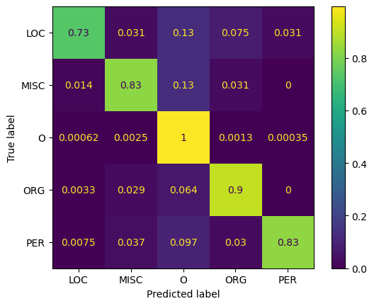

```python
def get_label(tag):
    if tag == "O":
        return "O"
    else:
        return tag[2:]


test_tags = [get_label(t) for d in test_docs for t in get_iob_tags(d)]
pred_tags = [get_label(t) for d in pred_docs for t in get_iob_tags(d)]

ConfusionMatrixDisplay.from_predictions(test_tags, pred_tags, normalize="true")
```

What are the most common entities?

```python
entities = Counter((ent.orth_, ent.label_) for doc in test_docs for ent in doc.ents)
entities.most_common(25)
```

```
[(('SEC', 'ORG'), 18),
 (('Exchange Act', 'MISC'), 18),
 (('DTC', 'ORG'), 16),
 (('Securities Act of 1933', 'MISC'), 15),
 (('U.S.', 'LOC'), 14),
 (('Securities and Exchange Commission', 'ORG'), 11),
 (('Securities Act', 'MISC'), 10),
 (('United States', 'LOC'), 9),
 (('FASB', 'ORG'), 8),
 (('Delaware', 'LOC'), 8),
 (('ASU', 'MISC'), 8),
 (('InsPro', 'MISC'), 8),
 (('Bank of America , N.A.', 'ORG'), 8),
 (('Securities Exchange Act of 1934', 'MISC'), 7),
 (('Form 10-K', 'MISC'), 7),
 (('JPMSI', 'ORG'), 6),
 (('Fidelity Advisor 403 ( b ) program', 'MISC'), 6),
 (('SunGard', 'ORG'), 6),
 (('Merrill Lynch & Co. , Inc.', 'ORG'), 6),
 (('SCBV', 'ORG'), 6),
 (('EWT', 'ORG'), 6),
 (('Fidelity', 'ORG'), 6),
 (('Equinix', 'ORG'), 5),
 (('Kansas City', 'LOC'), 5),
 (('Form 8-K', 'MISC'), 5)]
```

```python
[e for e in entities.most_common() if e[0][1] == "LOC"]
```

```
[(('U.S.', 'LOC'), 14),
 (('United States', 'LOC'), 9),
 (('Delaware', 'LOC'), 8),
 (('Kansas City', 'LOC'), 5),
 (('MO', 'LOC'), 4),
 (('Nevada', 'LOC'), 3),
 (('New York', 'LOC'), 2),
 (('Charlotte', 'LOC'), 2),
 (('North Carolina', 'LOC'), 2),
 (('Fifth Street', 'LOC'), 2),
 (('NW', 'LOC'), 2),
 (('Washington , DC', 'LOC'), 2),
 (('Pratt County', 'LOC'), 2),
 (('Kansas', 'LOC'), 2),
 (('West 10th Street', 'LOC'), 1),
 (('generally', 'LOC'), 1),
 (('accepted', 'LOC'), 1),
 (('accounting', 'LOC'), 1),
 (('principles', 'LOC'), 1),
 (('Foulk Road', 'LOC'), 1),
 (('Wilmington', 'LOC'), 1),
 (('Broad Street', 'LOC'), 1),
 (('Velocity Way', 'LOC'), 1),
 (('Foster City', 'LOC'), 1),
 (('CA', 'LOC'), 1),
 (('Westshore Boulevard', 'LOC'), 1),
 (('Tampa', 'LOC'), 1),
 (('FL', 'LOC'), 1),
 (('McGee', 'LOC'), 1),
 (('Missouri', 'LOC'), 1),
 (('The Commonwealth of Massachusetts', 'LOC'), 1),
 (('State of New York', 'LOC'), 1),
 (('State of Delaware', 'LOC'), 1),
 (('Cayman Islands', 'LOC'), 1),
 (('US', 'LOC'), 1),
 (('West Wacker Drive', 'LOC'), 1),
 (('Chicago', 'LOC'), 1),
 (('Illinois', 'LOC'), 1),
 (('Louisiana', 'LOC'), 1),
 (('Hong Kong', 'LOC'), 1),
 (('Switzerland', 'LOC'), 1),
 (('Bucks', 'LOC'), 1),
 (('Philadelphia', 'LOC'), 1),
 (('Montgomery Counties', 'LOC'), 1),
 (('Pennsylvania', 'LOC'), 1),
 (('Weiss', 'LOC'), 1),
 (('Asia', 'LOC'), 1),
 (('British Virgin Islands', 'LOC'), 1),
 (('Sawyer', 'LOC'), 1),
 (('Wildcat', 'LOC'), 1),
 (('Japan', 'LOC'), 1),
 (('City of Dallas', 'LOC'), 1),
 (('State of Texas', 'LOC'), 1),
 (('Morris Corporate Center III', 'LOC'), 1),
 (('Interpace Parkway', 'LOC'), 1),
 (('Parsippany', 'LOC'), 1),
 (('NJ', 'LOC'), 1),
 (('Grand Rapids', 'LOC'), 1),
 (('Massachusetts', 'LOC'), 1)]
```

```python
[e for e in entities.most_common() if e[0][1] == "PER"]
```

```
[(('Bisaro', 'PER'), 3),
 (('Mike Rollins', 'PER'), 3),
 (('Citi', 'PER'), 3),
 (('Investment', 'PER'), 3),
 (('Research', 'PER'), 3),
 (('James Altucher', 'PER'), 2),
 (('Tabatznik', 'PER'), 2),
 (('Altucher', 'PER'), 2),
 (('Taylor', 'PER'), 2),
 (('Wilkinson', 'PER'), 2),
 (('Stewart', 'PER'), 2),
 (('David B. Ramaker', 'PER'), 2),
 (('Lori A. Gwizdala', 'PER'), 2),
 (('Thomas W. Kohn', 'PER'), 2),
 (('Kenneth W. Johnson', 'PER'), 2),
 (('John E. Kessler', 'PER'), 2),
 (('James E. Tomczyk', 'PER'), 2),
 (('Dominic Monastiere', 'PER'), 2),
 (('Dan Kelly', 'PER'), 1),
 (('Turner', 'PER'), 1),
 (('Robert Heller H .', 'PER'), 1),
 (('S. Leland Dill', 'PER'), 1),
 (('Hal Dickout', 'PER'), 1),
 (('Michael P. Byrum', 'PER'), 1),
 (('Paul M. Bisaro', 'PER'), 1),
 (('Lorna Ferguson', 'PER'), 1),
 (('Bodine', 'PER'), 1),
 (('Michelson', 'PER'), 1),
 (('Shell', 'PER'), 1),
 (('Penhoet', 'PER'), 1),
 (('Joyce', 'PER'), 1),
 (('Buchen', 'PER'), 1),
 (('Jack Michelson', 'PER'), 1),
 (('Ronald R. Taylor', 'PER'), 1),
 (('Andrew L. Turner', 'PER'), 1),
 (('Scott Smith B .', 'PER'), 1),
 (('George Catch', 'PER'), 1),
 (('Jay L. Kloosterboer', 'PER'), 1),
 (('Gary E. Anderson', 'PER'), 1),
 (('James A. Currie', 'PER'), 1),
 (('Thomas T. Huff', 'PER'), 1),
 (('Thoma s T. Huff', 'PER'), 1),
 (('Keith Taylor', 'PER'), 1),
 (('Equinix', 'PER'), 1),
 ((',', 'PER'), 1),
 (('Inc.\x97CFO', 'PER'), 1),
 (('Kelly', 'PER'), 1)]
```

```python
[e for e in entities.most_common() if e[0][1] == "ORG"]
```

```
[(('SEC', 'ORG'), 18),
 (('DTC', 'ORG'), 16),
 (('Securities and Exchange Commission', 'ORG'), 11),
 (('FASB', 'ORG'), 8),
 (('Bank of America , N.A.', 'ORG'), 8),
 (('JPMSI', 'ORG'), 6),
 (('SunGard', 'ORG'), 6),
 (('Merrill Lynch & Co. , Inc.', 'ORG'), 6),
 (('SCBV', 'ORG'), 6),
 (('EWT', 'ORG'), 6),
 (('Fidelity', 'ORG'), 6),
 (('Equinix', 'ORG'), 5),
 (('Merck KGaA', 'ORG'), 5),
 (('Fidelity Advisor fund', 'ORG'), 5),
 (('Switch and Data', 'ORG'), 4),
 (('InsPro Technologies', 'ORG'), 4),
 (('New York Stock Exchange', 'ORG'), 4),
 (('CLARION VALUE FUND , Inc.', 'ORG'), 4),
 (('Chemical Financial', 'ORG'), 4),
 (('U.S. Treasury', 'ORG'), 3),
 (('Formula Capital', 'ORG'), 3),
 (('Deer Creek', 'ORG'), 3),
 (('ASC', 'ORG'), 3),
 (('DWS Investments', 'ORG'), 3),
 (('Moody', 'ORG'), 3),
 (('S & P', 'ORG'), 3),
 (('Corcept', 'ORG'), 3),
 (('J.P. Morgan Securities Inc.', 'ORG'), 3),
 (('Proxy Advisory', 'ORG'), 3),
 (('Arrow Group', 'ORG'), 3),
 (('J.P. Morgan Securities', 'ORG'), 3),
 (('JPMorgan Chase Bank , N.A.', 'ORG'), 3),
 (('Wachovia Bank , National Association', 'ORG'), 3),
 (('FDIC', 'ORG'), 3),
 (('Pericom', 'ORG'), 3),
 (('JPMIM', 'ORG'), 3),
 (('FormCap Advisory , LLC', 'ORG'), 2),
 (('Internal Revenue Service', 'ORG'), 2),
 (('Beauty Brands Group , Inc.', 'ORG'), 2),
 (('RPM', 'ORG'), 2),
```

[output cut: 216 more lines]

```
 (('Daniel', 'ORG'), 1),
 (('Bernson', 'ORG'), 1),
 (('The Hanson Group', 'ORG'), 1),
 (('Nancy', 'ORG'), 1),
 (('Bowman', 'ORG'), 1),
 (('Bowman & Rogers', 'ORG'), 1),
 (('Peregrine Realty , LLC', 'ORG'), 1),
 (('Peregrine Restaurant Group , LLC', 'ORG'), 1),
 (('CORT', 'ORG'), 1),
 (('InsPro Technologies Corporation', 'ORG'), 1),
 (('Darwin Resources Corp.', 'ORG'), 1),
 (('Darwin-NV', 'ORG'), 1),
 (('Carnegie Mellon University', 'ORG'), 1),
 (('Comerica Bank and World Omni Financial Corp.', 'ORG'), 1),
 (('Wells Fargo Bank National Association', 'ORG'), 1)]
```